# Gathering insights about COVID-19 Worldwide Testing using Linear Mixed Models

An analysis of linear mixed model algorithms and it’s applications

Author

Autumn Clark and Alex Ottley (Advisor: Dr.Cohen)

Published

April 29, 2025

Literature Review | Slides

## Introduction

This paper explores the theoretical foundations of linear mixed models (LMMs), their applications, and various techniques for estimating and interpreting the results. Additionally, we discuss model assumptions, challenges in fitting mixed models, and strategies to mitigate common pitfalls. Through these discussions, we aim to provide a comprehensive overview of LMMs and demonstrate their utility in addressing a range of research questions involving complex and correlated data.

Understanding complex, hierarchical data has become increasingly important across disciplines such as epidemiology, cardiology, psychology, and public health. Among the most powerful and flexible tools for analyzing such data is the Linear Mixed Model (LMM). LMMs extend traditional linear regression by incorporating both fixed effects, which account for population-level trends, and random effects, which capture variability across individual units or clusters. This structure enables LMMs to model correlated data—such as repeated measures from the same subject or observations nested within groups—without violating the assumption of independence required by simpler models.

The usefulness of LMMs is particularly evident in medical and health research, where individual variability is often substantial. For instance, (Goncalves et al. 2005) highlighted the superior performance of LMMs over ANOVA in evaluating heart rate and coronary-perfused pressure data in transgenic mice. Their work demonstrated how LMMs provide a more sensitive and robust framework for assessing experimental effects in biomedical studies, particularly when data are unbalanced or collected over time.

In cardiovascular research, sleep disturbances have been identified as significant contributors to abnormal nocturnal blood pressure (BP) profiles—factors that increase the risk of adverse cardiac events. (Matsumoto T 2019) employed LMMs in their investigation of sleep efficiency and nocturnal BP using multi-day observational data. Their use of random effects allowed them to control for between-subject variability while modeling day-to-day BP fluctuations, resulting in more accurate estimates of the associations. The study supported previous findings that lower sleep efficiency is linked to higher nighttime BP levels and diminished nocturnal BP dips (Kario et al. 2001) (Mano et al. 2021)

The advantages of LMMs extend to the modeling of 24-hour physiological processes. (Edwards and Simpson 2014) utilized orthonormal polynomials within LMMs to analyze 24-hour ambulatory blood pressure monitoring data. Their approach enhanced both the accuracy and interpretability of BP trajectories over time, providing clinicians with detailed insights into circadian rhythm variations in patient data. LMMs allowed for complex modeling without overfitting, an essential property when working with high-frequency longitudinal health data.

Moreover, LMMs have proven especially valuable in large-scale clinical outcomes research. (Wang et al. 2022) showcased the strength of LMMs using a dataset from over 600 patients who underwent pulmonary valve replacement surgery. With more than 5,000 echocardiographic measurements over multiple years, the study leveraged LMMs to model both fixed effects (e.g., treatment procedures, age, sex) and random effects (e.g., patient-specific recovery trajectories). LMMs allowed the researchers to handle missing data, unbalanced measurement schedules, and inter-patient heterogeneity more effectively than traditional linear models or survival analysis.

Together, these studies establish LMMs as a critical tool in longitudinal and repeated-measures research, offering flexibility, accuracy, and interpretability. This paper builds on that foundation by applying LMMs to the COVID-19 Worldwide Testing dataset, which contains country-level, time-indexed data on daily testing and positivity rates. While the subject differs from cardiovascular data, the analytical challenges—such as repeated observations, between-country variability, and time trends—are strikingly similar. The goal is to illustrate how LMMs can uncover meaningful patterns in large public health data sets, ultimately guiding more informed decision-making in times of global crisis. Later sections will also briefly reflect on how these models might be applied in hypothetical clinical settings, such as circadian blood pressure analysis.

## 2 Methods

Linear Mixed Models (LMMs) are a powerful statistical approach for analyzing data with both fixed and random effects, commonly used when observations are correlated or grouped (i.e., repeated measures, hierarchical data).

The selected dataset for this project represents repeated measures data, which is data that includes observations collected from the same variable (dependent variable) multiple times, either over time or under different conditions, allowing for analysis of changes or effects within those subjects.

The goal of this analysis is to present how COVID-19 testing relates to the number of positive cases across different countries. Although we expect a general relationship, more tests leading to more positive cases, the strength of that relationship likely varies from country to country due to differences in testing strategies, population size, healthcare infrastructure, and outbreak severity. To capture this country level variability, we apply a Linear Mixed Model framework, which allows us to analyze both overall trends and country-specific deviations. It is also important to recognize why we are using a Linear Mixed Model to answer this question. A traditional linear regression would present a single slope and intercept for all countries, which ignores the natural variation between regions. A LMM allows each country to have its own intercept or baseline number of positive cases. An LMM also allows each country to have its own slope which is presented as the effect of testing on positivity.

## 2.1 Understanding Linear Mixed Models

A Linear Mixed Model (LMM) is a flexible extension of the linear regression model that incorporates both fixed and random effects. Fixed effects represent population-level parameters that are constant across all groups (e.g., the average impact of daily testing across all countries). Random effects capture variation across clusters (e.g., countries), allowing each group to have its own intercept and/or slope. This is particularly useful for hierarchical, repeated-measures, or panel data, where observations within the same group are not independent.

LMMs are ideal for modeling data where residual errors are correlated within groups but independent across groups, which violates the assumptions of ordinary least squares (OLS) regression. They also allow analysts to partition variability into within-group and between-group components, improving both inference accuracy and generalizability.

## 2.2 Model Structure and Notation

The general form of a linear mixed model is:

$$y_{ij} = \beta_0 + \beta_1 x_{ij} + b_{0j} + b_{1j}x_{ij} + \varepsilon_{ij}$$
Where,

- $y_{ij}$: response variable for observation in $i$ in group $j$
- $x_{ij}$: predictor (e.g., scaled daily tests)
- $\beta_0,\beta_1$: fixed intercept and slope (population-level)
- $b_{0j}, b_{1j}$: random intercept and slope for group $j$ (e.g., country)
- $\varepsilon_{ij}$: residual error, assumed to be normally distributed: $\varepsilon_{ij} \sim N (0, \sigma^2)$

In matrix form, the LMM can be represented as:
$$y = X\beta + Zb + \varepsilon$$
Where,

- $y$: vector of outcomes
- $X$: fixed-effects design matrix
- $\beta$: vector of fixed effect coefficients
- $Z$: random-effects design matrix
- $b$: vector of random effects, assumed $\sim N (0, G)$
- $\varepsilon$: residual errors, assumed $\sim N(0, R)$

This framework enables the estimation of both overall trends (fixed effects) and group-specific deviations (random effects), making linear mixed models ideal for handling variability and correlation structures across clusters.

## 2.3 Assumptions

Like many statistical methods, Linear Mixed models rely on several assumptions to ensure validity of estimates and inferences. These assumptions include:

1. **Linearity** - the relationship between predictor (fixed effects) and response variable are linear.
2. **Independence of Residual Errors** - residual errors of a model are assumed to be independent within each level of the random effect structure
3. **Normality of Residual Errors and Random Effects** - Residual errors and random effects are assumed to be **normally distributed**.
4. **Homoscedasticity**, the variance of the residuals, should be **constant** across all levels of the independent variables.

## 2.4 Application to COVID-19 Data

In this study, we employed a linear mixed model to examine the relationship between the number of daily COVID-19 positive cases reported across various countries over time. The data set consists of repeated daily observations for each country, which results in multilevel structure where each country is considered a separate group with its own data points over time. This hierarchical structure gives the opportunity to account for both the overall trends in the data and the variability across different countries.

The model was designed to account for both the fixed effects of the number of daily tests conducted, which can influence case detection, and the random effects that capture country-specific deviations in testing practices and positivity rates. The model allows the both the intercept, baseline positivity, and the slope, the effect of testing on reported cases, to vary by country. This is incredibly important because different countries may have varying baseline rates of COVID-19 positivity and differing testing strategies, which may influence the number of positive cases detected.

### Key components of the model:

- Response variable: **daily_positive** — the number of newly confirmed cases per day
- Fixed effect predictor: **daily_tested_scaled** — the number of daily tests conducted (scaled by 1,000)
- Random effects: Intercept and slope for each **Country_Region**, allowing both baseline positivity and test effectiveness to vary by country

The model formula in R was specified as:

**lmer(daily_positive ~ daily_tested_scaled + (daily_tested_scaled | Country_Region), data = df_clean)*

This structure enables the model to capture both the overall trend of case detection as influenced by the number of tests conducted, while simultaneously accounting for the heterogeneity in testing practices and baseline positivity across countries. By allowing these country-level variations, the model provides a more accurate understanding of how COVID-19 testing impacted the reported cases in different settings.

## 2.5 Justification

Linear mixed models were chosen due to their ability to model nested data, adjust for within-group correlation, and incorporate individual variation in trends. These models also handle unbalanced data (i.e., unequal observations per country) and missingness better than traditional methods like repeated-measures ANOVA or fixed-effects OLS regression.

## 3 Analysis and Results

### 3.1 Data and Visualization

### Packages

```r
# loading packages
library(tidyverse)
library(knitr)
library(ggthemes)
library(ggrepel)
library(dslabs)
library(lme4)
library(nlme)
library(dplyr)
library(ggplot2)
library(readr)
```

### Data Import

```r
# Load Data
library(readr)
COVID19 <- read_csv("tested_worldwide.csv")
kable(head(COVID19))
```

| Date | Country_Region | Province_State | positive | active | hospitalized | hospitalizedCurr | recovered | death | total_tested | daily_tested | daily_positive |
| --- | --- | --- | --- | --- | --- | --- | --- | --- | --- | --- | --- |
| 2020-01-16 | Iceland | All States | 3 | NA | NA | NA | NA | NA | NA | NA | NA |
| 2020-01-17 | Iceland | All States | 4 | NA | NA | NA | NA | NA | NA | NA | 1 |
| 2020-01-18 | Iceland | All States | 7 | NA | NA | NA | NA | NA | NA | NA | 3 |
| 2020-01-20 | South Korea | All States | 1 | NA | NA | NA | NA | NA | 4 | NA | NA |
| 2020-01-22 | United States | All States | 0 | NA | NA | NA | NA | 0 | 0 | NA | NA |
| 2020-01-22 | United States | Massachusetts | 0 | NA | NA | NA | NA | 0 | 0 | NA | NA |

```r
df <- COVID19
```

Data Source: **Kaggle**

[Covid19 Worldwide Testing](https://www.kaggle.com/datasets/lin0li/covid19testing/data)

**Description:** Daily reported positive COVID-19 cases are commonly used as an indicator of how the virus spreads within a country and around the world. However, this data can be misleading because of the excessive amount of testing conducted. Research suggests that over 50% of COVID-19 infections could be asymptomatic, which means that a large number of individuals who are affected may not seek testing. This results in these individuals remaining undetected. The cases that get reported represent only a fraction of the actual infections in the population.

This highlights the need to account for testing volume when analyzing reported case data. A country with limited testing capacity/resources may report a low number of confirmed cases. This is not due to low transmissions rates, but because infections still remain undetected. To gain a more accurate understanding of the COVID-19 pandemic’s progression, it is very important to consider both the number of confirmed cases and the number of tests conducted each day/over time.

### 3.2 Exploratory Data Analysis (Clean Data)

```r
df <- COVID19
#Convert Date to Date format
df$Date <- as.Date(df$Date)

#Remove rows with missing values in relevant columns
df_clean <- df %>%
  filter(!is.na(daily_positive), !is.na(daily_tested), !is.na(Country_Region))

#Rescale daily_tested column to improve interpretation and convergence
df_clean$daily_tested_scaled <- df_clean$daily_tested / 1000
```

### 3.3 Model

```r
#Fit LMM with random intercept and slope
model_refined <- lmer(daily_positive ~ daily_tested_scaled + (daily_tested_scaled | Country_Region), data = df_clean)

head(df_clean)
```

```
# A tibble: 6 × 13
  Date       Country_Region Province_State positive active hospitalized
  <date>     <chr>          <chr>             <dbl>  <dbl>        <dbl>
1 2020-01-23 United States  All States            0     NA           NA
2 2020-01-23 United States  Massachusetts         0     NA           NA
3 2020-01-23 United States  Washington            0     NA           NA
4 2020-01-24 South Korea    All States            2     NA           NA
5 2020-01-24 United States  All States            0     NA           NA
6 2020-01-24 United States  Massachusetts         0     NA           NA
# ℹ 7 more variables: hospitalizedCurr <dbl>, recovered <dbl>, death <dbl>,
#   total_tested <dbl>, daily_tested <dbl>, daily_positive <dbl>,
#   daily_tested_scaled <dbl>
```

```r
#Model Summary
summary(model_refined)
```

```
Linear mixed model fit by REML ['lmerMod']
Formula: daily_positive ~ daily_tested_scaled + (daily_tested_scaled |
    Country_Region)
   Data: df_clean

REML criterion at convergence: 403653.6

Scaled residuals:
    Min      1Q  Median      3Q     Max
-16.395  -0.085  -0.029   0.026  32.703

Random effects:
 Groups         Name                Variance Std.Dev. Corr
 Country_Region (Intercept)          435521   659.94
                daily_tested_scaled    4217    64.94  -0.42
 Residual                           2977310  1725.49
Number of obs: 22735, groups:  Country_Region, 108

Fixed effects:
                    Estimate Std. Error t value
(Intercept)            95.05      87.80   1.083
daily_tested_scaled    52.16      10.93   4.774

Correlation of Fixed Effects:
            (Intr)
dly_tstd_sc -0.468
optimizer (nloptwrap) convergence code: 0 (OK)
Model failed to converge with max|grad| = 0.003381 (tol = 0.002, component 1)
```

### 3.3.1 Model Specification

We modeled the number of daily positive COVID-19 cases (daily_positive) as a function of the number of daily tests conducted (daily_tested_scaled). We fit a Linear Mixed Model (LMM) with a random intercept and random slope for each country:

- Response variable: *daily_positive*
- Fixed effect predictor: *daily_tested_scaled* (daily tests per 1,000)
- Random effects: intercepts and slopes grouped by *Country_Region*

This model allows each country to have its own baseline number of positive cases and its own relationship between testing volume and positivity.

### 3.4 Fixed Effects Interpretation

```r
#Extract and print key fixed effects
fixef(model_refined) #estimates for population-level intercept and slope
```

```
        (Intercept) daily_tested_scaled
           95.05436            52.16033
```

The fixed effect for *daily_tested_scaled* was statistically significant (Estimate = 52.16, SE = 10.93, p < 0.001), indicating that, on average, each additional 1,000 tests is associated with approximately 52 more reported positive cases. The fixed intercept was not statistically significant (Estimate = 95.05, p = 0.281), suggesting no strong global baseline when adjusting for testing.

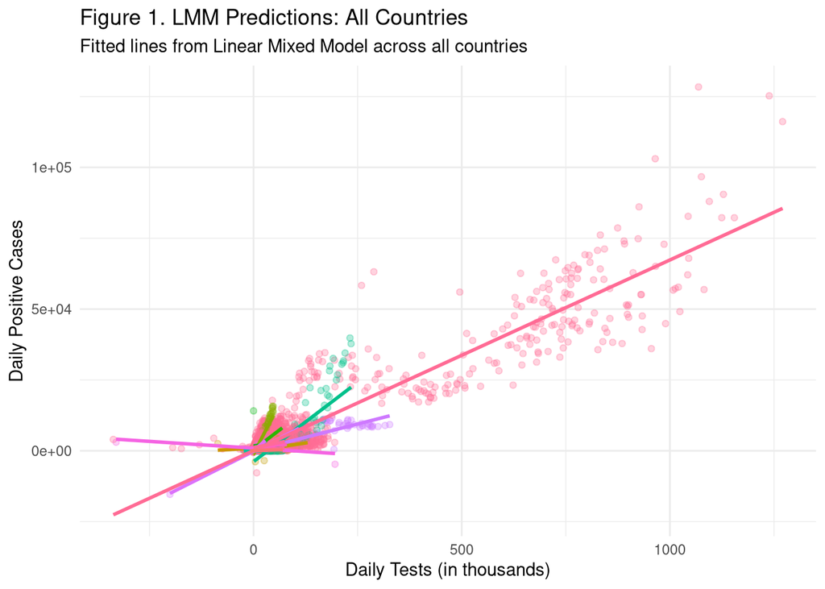

```r
#Generate model prediction
df_clean$predicted <- predict(model_refined)

#Plot all countries
ggplot(df_clean, aes(x = daily_tested_scaled, y = daily_positive, color = Country_Region)) +
  geom_point(alpha = 0.3) +
  geom_line(aes(y = predicted, group = Country_Region), linewidth = 1) +
  labs(
    title = "Figure 1. LMM Predictions: All Countries",
    subtitle = "Fitted lines from Linear Mixed Model across all countries",
    x = "Daily Tests (in thousands)",
    y = "Daily Positive Cases"
  ) +
  theme_minimal() +
  theme(legend.position = "none")
```

### 3.5 Random Effects Interpretation

```r
VarCorr(model_refined)
```

```
 Groups         Name                Std.Dev. Corr
 Country_Region (Intercept)          659.941
                daily_tested_scaled   64.935 -0.423
 Residual                           1725.488
```

The random intercept variance was 435,521 (SD = 659.94), indicating substantial variability in baseline positivity rates across countries. The random slope variance for daily_tested_scaled was 4,217 (SD = 64.94), suggesting that the effectiveness of testing (i.e., how many positives are identified per test) varies significantly by country. The negative correlation (-0.42) between random intercepts and slopes suggests that countries with higher baseline positivity tend to have a smaller marginal gain in detected positives per test.

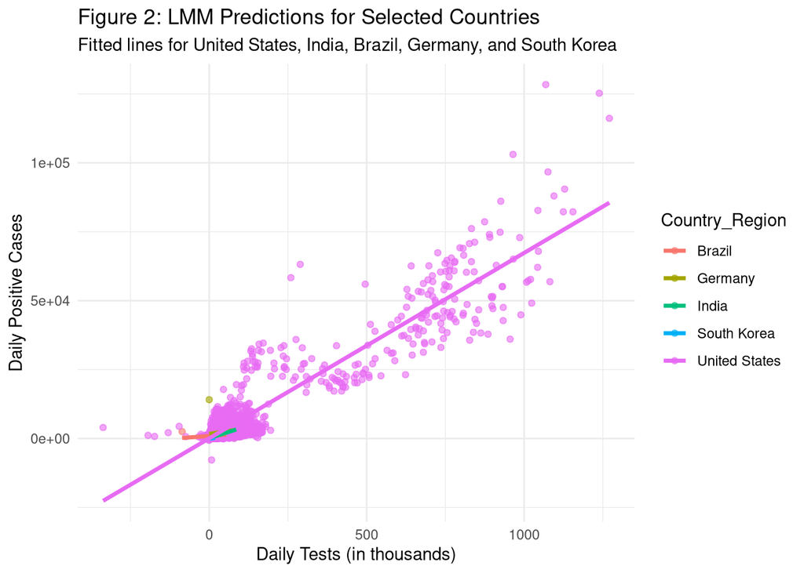

```r
# Select a subset of countries
selected_countries <- c("United States", "India", "Brazil", "Germany", "South Korea")
df_subset <- df_clean[df_clean$Country_Region %in% selected_countries, ]

# Generate predictions for selected countries
df_subset$predicted <- predict(model_refined, newdata = df_subset)

# Plot
ggplot(df_subset, aes(x = daily_tested_scaled, y = daily_positive, color = Country_Region)) +
  geom_point(alpha = 0.6) +  # Raw data points
  geom_line(aes(y = predicted), linewidth = 1.2) +  # Use linewidth instead of size
  labs(
    title = "Figure 2: LMM Predictions for Selected Countries",
       subtitle = "Fitted lines for United States, India, Brazil, Germany, and South Korea",
    x = "Daily Tests (in thousands)",
    y = "Daily Positive Cases") +
  theme_minimal()
```

This scatterplot shows the relationship between testing and positive cases for specific countries and the country-wise differences in slopes (e.g., some countries have steeper slopes than others). In addition, this scatterplot shows how the model predicts positivity rates differently per country.

### 4 Conclusion

This study applied a Linear Mixed Model (LMM) to analyze COVID-19 testing data across countries using time-indexed, repeated measures. By modeling daily positive case counts as a function of daily testing volume and allowing both intercepts and slopes to vary by country, the LMM effectively captured differences in baseline positivity and testing effectiveness across global regions.

The fixed effect results demonstrated that increased testing was significantly associated with higher detected case counts, underscoring the critical role that testing plays in understanding and managing the spread of COVID-19. Additionally, the model’s random effects revealed meaningful variation between countries—both in baseline levels of positive cases and in how each country’s positivity rate responded to increased testing.

Overall, the use of LMMs in this context illustrates their power in handling real-world public health data that is hierarchical, unbalanced, and repeated over time. The flexibility of LMMs allows researchers to extract more meaningful insights than would be possible with simpler linear models or ANOVA, particularly when assessing country-specific patterns during a global health crisis. Future research might explore more complex temporal structures or additional covariates (e.g., vaccination rates, policy interventions) to further enhance our understanding of COVID-19 dynamics worldwide.

## 5 References

Miki, T., et al. (2022). Nocturnal urination and its impact on sleep and blood pressure. Journal of Sleep Research, 31(4), e13489.

## References

Bates, Douglas et al. 2005. “Fitting Linear Mixed Models in r.” *R News* 5 (1): 27–30.

Edwards, L. J., and S. L. Simpson. 2014. “An Analysis of 24-h Ambulatory Blood Pressure Monitoring Data Using Orthonormal Polynomials in the Linear Mixed Model.” *Blood Pressure Monitoring* 19: 153–63. https://doi.org/10.1097/mbp.0000000000000039.

Goncalves, Paulo, Christophe Lenoir, Christophe Heymes, Bernard Swynghedauw, and Christian Lavergne. 2005. “Statistical Modelling of Cardiovascular Data. An Introduction to Linear Mixed Models,” no. RR-5787 (December): 21. https://inria.hal.science/inria-00070234.

Kario, K, Y Ohno, K Shimada, K Nakayama, and K Shimamoto. 2001. “Nocturnal Blood Pressure Dipping and Cardiovascular Risk.” *Hypertension* 37 (4): 1000–1005. https://doi.org/10.1161/01.HYP.37.4.1000.

Mano, T. et al. 2021. “Sleep Fragmentation and Cardiovascular Risk: A Review of Current Literature.” *Sleep Medicine Reviews* 55: 101384.

Matsumoto T, Murase K, Tabara Y. 2019. “Association Between Sleep Disturbance and Nocturnal Blood Pressure Profiles by a Linear Mixed Model Analysis: The Nagahama Study.” *Sleep Medicine* 61: 104–9. https://doi.org/https://doi.org/10.1016/j.sleep.2019.01.049.

Wang, Xu, Eleni-Rosalina Andrinopoulou, Kevin M Veen, Ad J J C Bogers, and Johanna J M Takkenberg. 2022. “Statistical Primer: An Introduction to the Application of Linear Mixed-Effects Models in Cardiothoracic Surgery Outcomes Research‚äîa Case Study Using Homograft Pulmonary Valve Replacement Data.” *European Journal of Cardio-Thoracic Surgery* 62 (4): ezac429. https://doi.org/10.1093/ejcts/ezac429.